# part C

## STM Effect Estimation

```r
# Estimate the effects of price and review score
# on topic probability

effects <- estimateEffect(~review_scores_rating+price,
                          stmobj = newyorkfit,
                          metadata = out$meta)
```

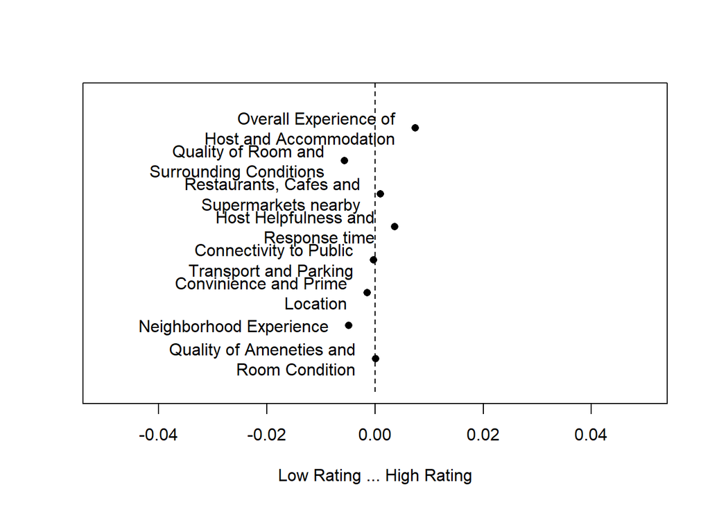

```r
# Effect of review score on topic
# probability
plot(effects, covariate = "review_scores_rating",
     topics = c(1:8),
     model = newyorkfit, method = "difference",
     cov.value1 = "100", cov.value2 = "0",
     xlab = "Low Rating ... High Rating",
     xlim = c(-0.05,0.05),
     main = "",
     ci.level = 0.05,
     custom.labels =topic_labels[c(1:8)],
     labeltype = "custom")
```

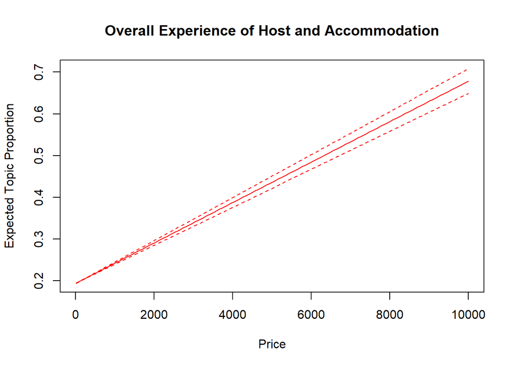

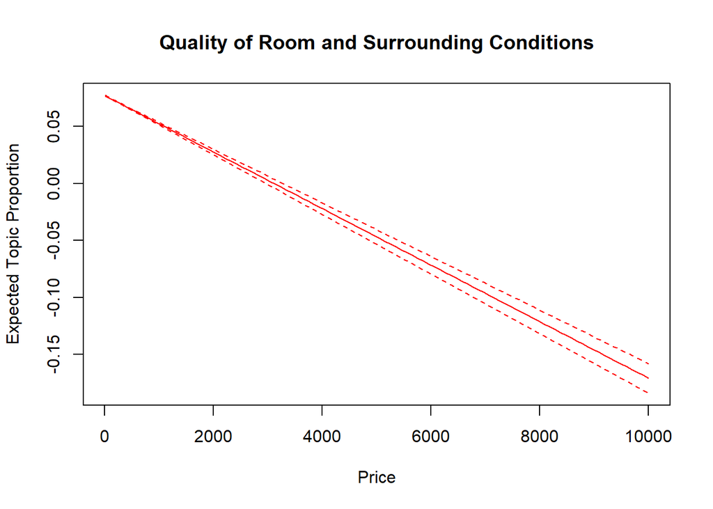

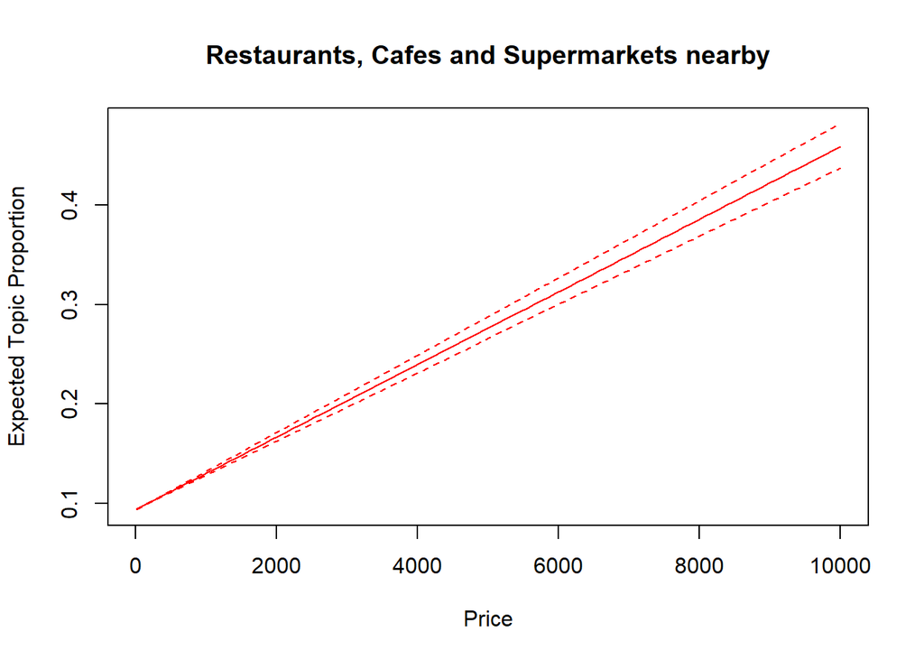

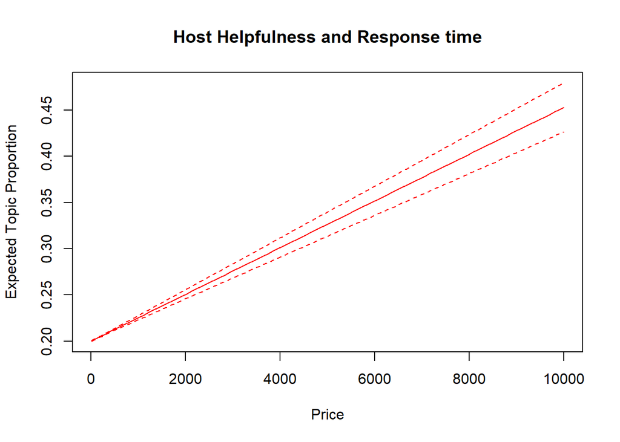

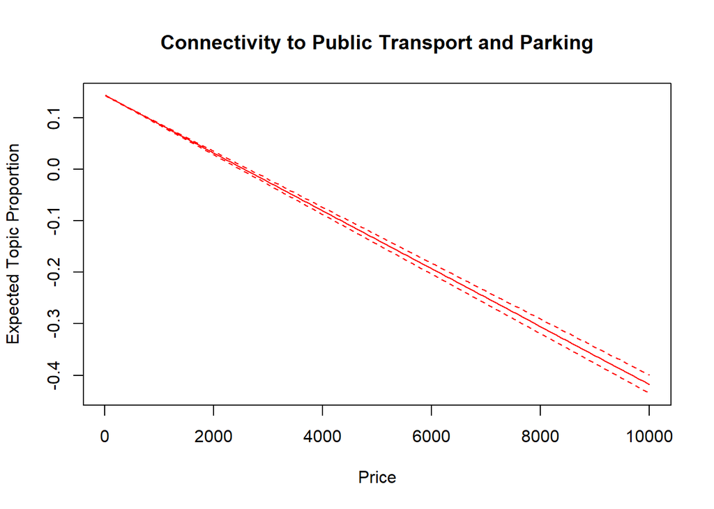

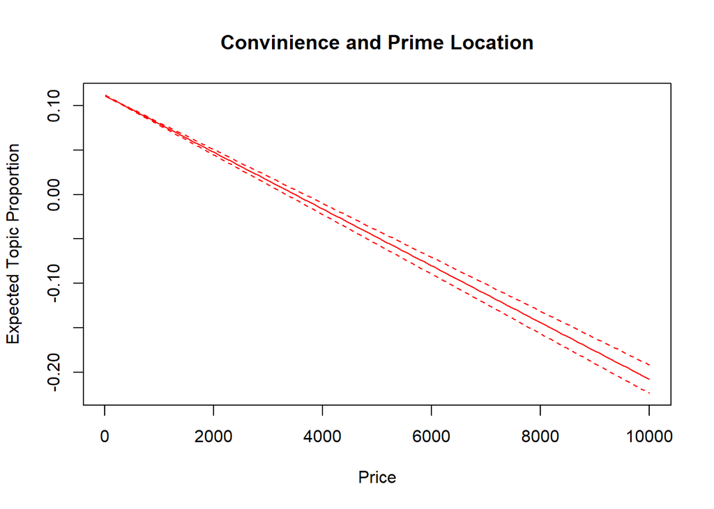

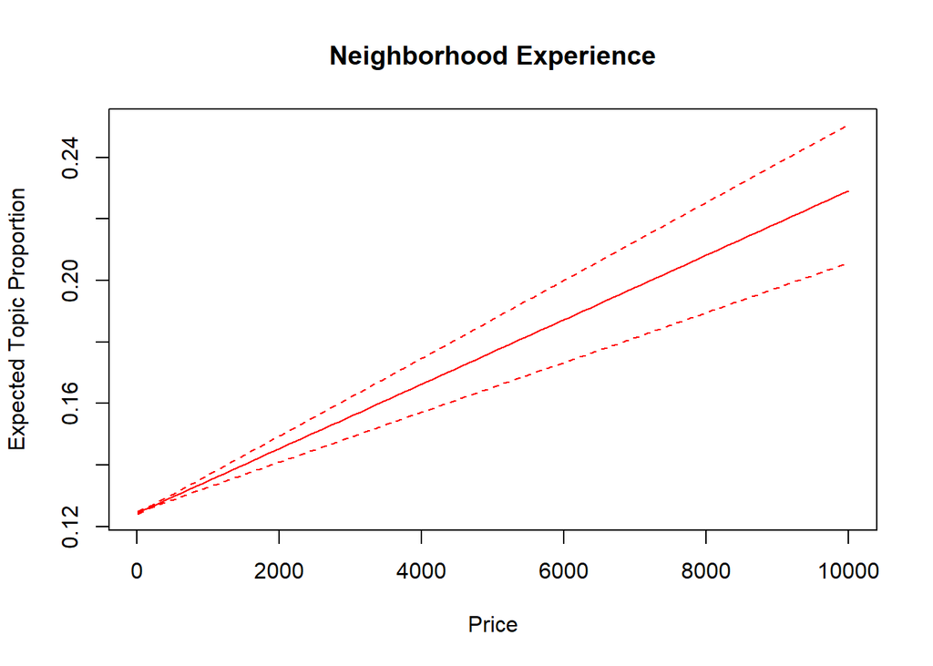

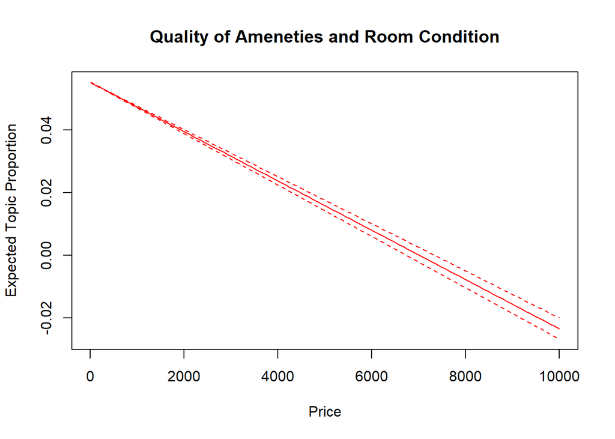

```r
# Effect of price on topic
# probability treating price as
# a continuous variable.
#
# Ploting each topic separately
# we can see that some of them increase
# substantially with the price

for(i in 1:length(topic_labels)){
plot(effects, covariate = "price",
     topics = i,
     model = airbnbfit, method = "continuous",
     # For this plotting we get the uper quantile
     # and low quantile of the price
     xlab = "Price",
     # xlim = c(0,800),
     main = topic_labels[i],
     printlegend = FALSE,
     custom.labels =topic_labels[i],
     labeltype = "custom")
}
```

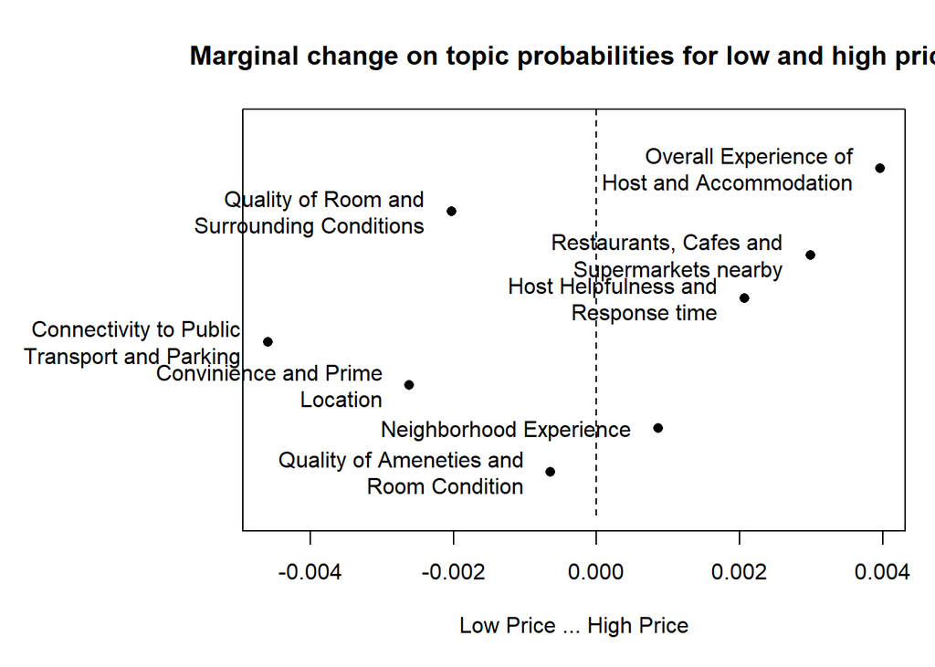

```r
# Lets also plot them as a contrast between
# the minimum and maximum price
# for that we need the margins of the upper and lower quantile
margin1 <- as.numeric(quantile(out$meta$price)[2])
margin2 <- as.numeric(quantile(out$meta$price)[4])


par(mar=c(5,9,4,1)+.1)
plot(effects, covariate = "price",
     topics = c(1:8),
     model = newyorkfit, method = "difference",
     cov.value1 = margin2, cov.value2 = margin1,
     xlab = "Low Price ... High Price",
     # xlim = c(-0.01,0.01),
     main = "Marginal change on topic probabilities for low and high price",
     custom.labels =topic_labels,
     ci.level = 0.05,
     labeltype = "custom")
```

```r
# Finding number  amenities, bathrooms
i <- 1
for (i in 1:length(listings_detailed$host_verifications)) {

  listings_detailed$num_amenities[i] <- length(strsplit(listings_detailed$amenities[i], split= " ")[[1]])
  listings_detailed$num_bath[i] <- as.numeric(gsub("[^0-9.]", "",listings_detailed$bathrooms_text[i]))
    i <- i+1
}

all_sentiments <- readr::read_csv("sentiments.csv")

listings_detailed %>% dplyr::select(listing_id,num_bath,num_amenities,beds, room_type) -> var_data

var <- all_sentiments %>% left_join(var_data)
var <- var %>% na.omit()
```

```r
# We allready have the price and occupancy rate
# What we are going to do now is to regress price and occupancy rate from
# part B and this time we are going to add the average topic membership for this month

# Lets merge the dataframe: to_regress_sentiment_price_occ
# with the topic probabilities
# to do that we access again the stm object with each metadata for each topic
# do not forget that we need the review date as well
# so we average it by month and year.

stm_object<- newyorkfit$theta
# remember that we just rename the column names for the
# topics so we have a better naming convention than just
# '1' or '2' etc.
colnames(stm_object) <- topic_labels

# date_df <- reviews_pre_corona_metadata %>%
#   select(listing_id, date)

causal_topic_df <- cbind(out$meta,stm_object)

# convert the date object to the month year format
#causal_topic_df$month_year <- format(causal_topic_df$date,"%Y-%m")





# Bonus point if you find a smarter way to
# create topic summaries
causal_topic_df %>%
  left_join(var) %>%
  na.omit() -> regress_stm_price_review

regress_stm_price_review <- regress_stm_price_review %>% dplyr::select(-c(listing_id, X1, review_id, comments_grouped))
```

```r
model_search_review <- lm(review_scores_rating~.,data=regress_stm_price_review)
MASS::stepAIC(model_search_review)
```

Start: AIC=596827 review_scores_rating ~ price + `Overall Experience of Host and Accommodation` + `Quality of Room and Surrounding Conditions` + `Restaurants, Cafes and Supermarkets nearby` + `Host Helpfulness and Response time` + `Connectivity to Public Transport and Parking` + `Convinience and Prime Location` + `Neighborhood Experience` + `Quality of Ameneties and Room Condition` + total_excl_count + bing_liu_sentiment + nrc_sentiment + afinn_sentiment + loughran_sentiment + num_bath + num_amenities + beds + room_type

Step: AIC=596827 review_scores_rating ~ price + `Overall Experience of Host and Accommodation` + `Quality of Room and Surrounding Conditions` + `Restaurants, Cafes and Supermarkets nearby` + `Host Helpfulness and Response time` + `Connectivity to Public Transport and Parking` + `Convinience and Prime Location` + `Neighborhood Experience` + total_excl_count + bing_liu_sentiment + nrc_sentiment + afinn_sentiment + loughran_sentiment + num_bath + num_amenities + beds + room_type

[output not shown]

Step: AIC=596825.7 review_scores_rating ~ `Overall Experience of Host and Accommodation` + `Quality of Room and Surrounding Conditions` + `Restaurants, Cafes and Supermarkets nearby` + `Host Helpfulness and Response time` + `Connectivity to Public Transport and Parking` + `Convinience and Prime Location` + `Neighborhood Experience` + total_excl_count + bing_liu_sentiment + nrc_sentiment + afinn_sentiment + loughran_sentiment + num_bath + num_amenities + beds + room_type

[output not shown]

Call: lm(formula = review_scores_rating ~ `Overall Experience of Host and Accommodation` + `Quality of Room and Surrounding Conditions` + `Restaurants, Cafes and Supermarkets nearby` + `Host Helpfulness and Response time` + `Connectivity to Public Transport and Parking` + `Convinience and Prime Location` + `Neighborhood Experience` + total_excl_count + bing_liu_sentiment + nrc_sentiment + afinn_sentiment + loughran_sentiment + num_bath + num_amenities + beds + room_type, data = regress_stm_price_review)

Coefficients: (Intercept)  
132.339645  
`Overall Experience of Host and Accommodation`  
-47.930850  
`Quality of Room and Surrounding Conditions`  
-62.573406  
`Restaurants, Cafes and Supermarkets nearby`  
-50.202915  
`Host Helpfulness and Response time`  
-49.313106  
`Connectivity to Public Transport and Parking`  
-53.110718  
`Convinience and Prime Location`  
-52.520511  
`Neighborhood Experience`  
-53.726889  
total_excl_count  
0.007925  
bing_liu_sentiment  
11.756275  
nrc_sentiment  
1.156498  
afinn_sentiment  
0.015315  
loughran_sentiment  
0.259930  
num_bath  
0.263504  
num_amenities  
0.026202  
beds  
-0.172228  
room_typeHotel room  
-1.695830  
room_typePrivate room  
-0.215179  
room_typeShared room  
0.575567

```r
summary(lm(review_scores_rating ~ price + `Overall Experience of Host and Accommodation` +
    `Quality of Room and Surrounding Conditions` + `Restaurants, Cafes and Supermarkets nearby` +
    `Host Helpfulness and Response time` + `Connectivity to Public Transport and Parking` +
    `Convinience and Prime Location` + `Neighborhood Experience` +
    total_excl_count + bing_liu_sentiment + nrc_sentiment + afinn_sentiment +
    loughran_sentiment + num_bath + num_amenities + beds + room_type,
    data = regress_stm_price_review))
```

```
##
## Call:
## lm(formula = review_scores_rating ~ price + `Overall Experience of Host and Accommodation` +
##     `Quality of Room and Surrounding Conditions` + `Restaurants, Cafes and Supermarkets nearby` +
##     `Host Helpfulness and Response time` + `Connectivity to Public Transport and Parking` +
##     `Convinience and Prime Location` + `Neighborhood Experience` +
##     total_excl_count + bing_liu_sentiment + nrc_sentiment + afinn_sentiment +
##     loughran_sentiment + num_bath + num_amenities + beds + room_type,
##     data = regress_stm_price_review)
##
## Residuals:
##     Min      1Q  Median      3Q     Max
## -55.154  -1.355   0.212   1.616  17.458
##
## Coefficients:
##                                                  Estimate Std. Error t value
## (Intercept)                                     1.325e+02  7.435e-01 178.163
## price                                           2.136e-05  2.560e-05   0.834
## `Overall Experience of Host and Accommodation` -4.807e+01  7.819e-01 -61.478
## `Quality of Room and Surrounding Conditions`   -6.271e+01  8.035e-01 -78.048
## `Restaurants, Cafes and Supermarkets nearby`   -5.035e+01  7.898e-01 -63.747
## `Host Helpfulness and Response time`           -4.945e+01  7.896e-01 -62.631
## `Connectivity to Public Transport and Parking` -5.325e+01  8.050e-01 -66.146
## `Convinience and Prime Location`               -5.266e+01  7.939e-01 -66.331
## `Neighborhood Experience`                      -5.387e+01  7.861e-01 -68.523
## total_excl_count                                7.925e-03  1.238e-04  64.031
## bing_liu_sentiment                              1.175e+01  6.053e-02 194.210
## nrc_sentiment                                   1.158e+00  6.891e-02  16.810
## afinn_sentiment                                 1.531e-02  1.875e-04  81.667
## loughran_sentiment                              2.593e-01  3.252e-02   7.973
## num_bath                                        2.616e-01  1.562e-02  16.743
## num_amenities                                   2.621e-02  2.796e-04  93.736
## beds                                           -1.726e-01  4.591e-03 -37.585
## room_typeHotel room                            -1.698e+00  8.449e-02 -20.095
## room_typePrivate room                          -2.139e-01  1.059e-02 -20.204
## room_typeShared room                            5.767e-01  3.987e-02  14.465
##                                                Pr(>|t|)
## (Intercept)                                     < 2e-16 ***
## price                                             0.404
## `Overall Experience of Host and Accommodation`  < 2e-16 ***
```

[output cut: 8 more lines]

```
## nrc_sentiment                                   < 2e-16 ***
## afinn_sentiment                                 < 2e-16 ***
## loughran_sentiment                             1.55e-15 ***
## num_bath                                        < 2e-16 ***
## num_amenities                                   < 2e-16 ***
## beds                                            < 2e-16 ***
## room_typeHotel room                             < 2e-16 ***
## room_typePrivate room                           < 2e-16 ***
## room_typeShared room                            < 2e-16 ***
## ---
## Signif. codes:  0 '***' 0.001 '**' 0.01 '*' 0.05 '.' 0.1 ' ' 1
##
## Residual standard error: 2.609 on 311149 degrees of freedom
## Multiple R-squared:  0.5425, Adjusted R-squared:  0.5425
## F-statistic: 1.942e+04 on 19 and 311149 DF,  p-value: < 2.2e-16
```

```r
model_search_price <- lm(price~.,data=regress_stm_price_review)
MASS::stepAIC(model_search_price)
```

```
## Start:  AIC=3241161
## price ~ review_scores_rating + `Overall Experience of Host and Accommodation` +
##     `Quality of Room and Surrounding Conditions` + `Restaurants, Cafes and Supermarkets nearby` +
##     `Host Helpfulness and Response time` + `Connectivity to Public Transport and Parking` +
##     `Convinience and Prime Location` + `Neighborhood Experience` +
##     `Quality of Ameneties and Room Condition` + total_excl_count +
##     bing_liu_sentiment + nrc_sentiment + afinn_sentiment + loughran_sentiment +
##     num_bath + num_amenities + beds + room_type
##
##
## Step:  AIC=3241161
## price ~ review_scores_rating + `Overall Experience of Host and Accommodation` +
##     `Quality of Room and Surrounding Conditions` + `Restaurants, Cafes and Supermarkets nearby` +
##     `Host Helpfulness and Response time` + `Connectivity to Public Transport and Parking` +
##     `Convinience and Prime Location` + `Neighborhood Experience` +
##     total_excl_count + bing_liu_sentiment + nrc_sentiment + afinn_sentiment +
##     loughran_sentiment + num_bath + num_amenities + beds + room_type
##
##                                                  Df Sum of Sq        RSS
## - total_excl_count                                1      8786 1.0389e+10
## - review_scores_rating                            1     23250 1.0389e+10
## <none>                                                        1.0389e+10
## - afinn_sentiment                                 1    127081 1.0389e+10
## - loughran_sentiment                              1   6084599 1.0395e+10
## - num_amenities                                   1   6719516 1.0396e+10
## - bing_liu_sentiment                              1   7177063 1.0396e+10
## - nrc_sentiment                                   1  10314539 1.0400e+10
## - beds                                            1  84148383 1.0473e+10
## - room_type                                       3 229452126 1.0619e+10
## - num_bath                                        1 237153402 1.0626e+10
## - `Quality of Room and Surrounding Conditions`    1 450558346 1.0840e+10
## - `Connectivity to Public Transport and Parking`  1 450787239 1.0840e+10
## - `Convinience and Prime Location`                1 456377927 1.0846e+10
## - `Host Helpfulness and Response time`            1 490505839 1.0880e+10
## - `Neighborhood Experience`                       1 495200941 1.0885e+10
## - `Overall Experience of Host and Accommodation`  1 499613832 1.0889e+10
## - `Restaurants, Cafes and Supermarkets nearby`    1 516978419 1.0906e+10
##                                                      AIC
## - total_excl_count                               3241160
## - review_scores_rating                           3241160
```

[output cut: 89 more lines]

```
## - afinn_sentiment                                3241165
## - loughran_sentiment                             3241342
## - num_amenities                                  3241360
## - bing_liu_sentiment                             3241415
## - nrc_sentiment                                  3241465
## - beds                                           3243676
## - room_type                                      3247960
## - num_bath                                       3248211
## - `Connectivity to Public Transport and Parking` 3254541
## - `Quality of Room and Surrounding Conditions`   3254606
## - `Convinience and Prime Location`               3254704
## - `Host Helpfulness and Response time`           3255674
## - `Neighborhood Experience`                      3255846
## - `Overall Experience of Host and Accommodation` 3255932
## - `Restaurants, Cafes and Supermarkets nearby`   3256447
```

```
##
## Call:
## lm(formula = price ~ `Overall Experience of Host and Accommodation` +
##     `Quality of Room and Surrounding Conditions` + `Restaurants, Cafes and Supermarkets nearby` +
##     `Host Helpfulness and Response time` + `Connectivity to Public Transport and Parking` +
##     `Convinience and Prime Location` + `Neighborhood Experience` +
##     bing_liu_sentiment + nrc_sentiment + afinn_sentiment + loughran_sentiment +
##     num_bath + num_amenities + beds + room_type, data = regress_stm_price_review)
##
## Coefficients:
##                                    (Intercept)
##                                     -6.108e+03
## `Overall Experience of Host and Accommodation`
##                                      6.578e+03
##   `Quality of Room and Surrounding Conditions`
##                                      6.456e+03
##   `Restaurants, Cafes and Supermarkets nearby`
##                                      6.757e+03
##           `Host Helpfulness and Response time`
##                                      6.586e+03
## `Connectivity to Public Transport and Parking`
##                                      6.453e+03
##               `Convinience and Prime Location`
##                                      6.401e+03
##                      `Neighborhood Experience`
##                                      6.595e+03
##                             bing_liu_sentiment
##                                      6.731e+01
##                                  nrc_sentiment
##                                     -8.458e+01
##                                afinn_sentiment
##                                      2.303e-02
##                             loughran_sentiment
##                                      3.086e+01
##                                       num_bath
##                                      9.126e+01
##                                  num_amenities
##                                     -2.791e-01
##                                           beds
##                                      1.610e+01
##                            room_typeHotel room
##                                      9.564e+01
##                          room_typePrivate room
##                                     -5.853e+01
##                           room_typeShared room
##                                     -5.154e+01
```

```r
summary(lm(price ~ review_scores_rating + `Overall Experience of Host and Accommodation` +
    `Quality of Room and Surrounding Conditions` + `Restaurants, Cafes and Supermarkets nearby` +
    `Host Helpfulness and Response time` + `Connectivity to Public Transport and Parking` +
    `Convinience and Prime Location` + `Neighborhood Experience` +
    total_excl_count + bing_liu_sentiment + nrc_sentiment + afinn_sentiment +
    loughran_sentiment + num_bath + num_amenities + beds + room_type,
    data = regress_stm_price_review))
```

```
##
## Call:
## lm(formula = price ~ review_scores_rating + `Overall Experience of Host and Accommodation` +
##     `Quality of Room and Surrounding Conditions` + `Restaurants, Cafes and Supermarkets nearby` +
##     `Host Helpfulness and Response time` + `Connectivity to Public Transport and Parking` +
##     `Convinience and Prime Location` + `Neighborhood Experience` +
##     total_excl_count + bing_liu_sentiment + nrc_sentiment + afinn_sentiment +
##     loughran_sentiment + num_bath + num_amenities + beds + room_type,
##     data = regress_stm_price_review)
##
## Residuals:
##    Min     1Q Median     3Q    Max
## -559.2  -50.6   -7.1   34.2 9453.8
##
## Coefficients:
##                                                  Estimate Std. Error  t value
## (Intercept)                                    -6.122e+03  5.355e+01 -114.312
## review_scores_rating                            1.048e-01  1.256e-01    0.834
## `Overall Experience of Host and Accommodation`  6.583e+03  5.382e+01  122.323
## `Quality of Room and Surrounding Conditions`    6.462e+03  5.563e+01  116.163
## `Restaurants, Cafes and Supermarkets nearby`    6.762e+03  5.434e+01  124.431
## `Host Helpfulness and Response time`            6.591e+03  5.438e+01  121.203
## `Connectivity to Public Transport and Parking`  6.458e+03  5.558e+01  116.192
## `Convinience and Prime Location`                6.407e+03  5.480e+01  116.910
## `Neighborhood Experience`                       6.600e+03  5.420e+01  121.782
## total_excl_count                               -4.476e-03  8.725e-03   -0.513
## bing_liu_sentiment                              6.579e+01  4.487e+00   14.661
## nrc_sentiment                                  -8.482e+01  4.826e+00  -17.576
## afinn_sentiment                                 2.590e-02  1.327e-02    1.951
## loughran_sentiment                              3.074e+01  2.277e+00   13.499
## num_bath                                        9.121e+01  1.082e+00   84.276
## num_amenities                                  -2.816e-01  1.985e-02  -14.186
## beds                                            1.612e+01  3.210e-01   50.201
## room_typeHotel room                             9.583e+01  5.919e+00   16.191
## room_typePrivate room                          -5.850e+01  7.346e-01  -79.634
## room_typeShared room                           -5.159e+01  2.792e+00  -18.483
##                                                Pr(>|t|)
## (Intercept)                                      <2e-16 ***
## review_scores_rating                             0.4040
## `Overall Experience of Host and Accommodation`   <2e-16 ***
```

[output cut: 8 more lines]

```
## nrc_sentiment                                    <2e-16 ***
## afinn_sentiment                                  0.0511 .
## loughran_sentiment                               <2e-16 ***
## num_bath                                         <2e-16 ***
## num_amenities                                    <2e-16 ***
## beds                                             <2e-16 ***
## room_typeHotel room                              <2e-16 ***
## room_typePrivate room                            <2e-16 ***
## room_typeShared room                             <2e-16 ***
## ---
## Signif. codes:  0 '***' 0.001 '**' 0.01 '*' 0.05 '.' 0.1 ' ' 1
##
## Residual standard error: 182.7 on 311149 degrees of freedom
## Multiple R-squared:  0.168,  Adjusted R-squared:  0.168
## F-statistic:  3308 on 19 and 311149 DF,  p-value: < 2.2e-16
```